# Differential Expression Analysis strategy comparison for Data-driven analysis of isobarically labeled proteomic data.

Joris Van Houtven, Piotr Prostko

January 13, 2021,22:16

```r
library(ggplot2)
library(stringi)
library(gridExtra)
library(dendextend)
library(kableExtra)
library(limma)
library(psych)
library(tidyverse)
library(CONSTANd)  # install from source: https://github.com/PDiracDelta/CONSTANd/
library(matrixTests)
library(coin)
library(ROTS)
source('./other_functions.R')
source('./plotting_functions.R')
```

```r
# set load_outputdata=TRUE if you want to skip long computations (normalization and DEA) and just load the previously saved data sets
load_outputdata=TRUE
data.list <- readRDS('input_data.rds')
dat.l <- data.list$dat.l # data in long format
# which proteins were spiked in?
spiked.proteins <- dat.l %>% distinct(Protein) %>% filter(stri_detect(Protein, fixed='ups')) %>% pull %>% as.character
#TEMP -remove!
# tmp=dat.l %>% distinct(Protein) %>% pull %>% as.character
# dat.l <- dat.l %>% filter(Protein %in% c(tmp[sample(1:length(tmp), size=20)], spiked.proteins))
```

```r
# specify # of varying component variants and their names
variant.names <- c('moderated_ttest', 'Wilcoxon', 'permutation_test', 'ROTS')
n.comp.variants <- length(variant.names)
scale.vec <- 'log'
# pick reference channel and condition for making plots / doing DEA
referenceCondition <- '0.5'
# specify colours corresponding to biological conditions
condition.color <- tribble(
  ~Condition, ~Color,
  "0.125", 'black',
  "0.5", 'blue',
  "0.667", 'green',
  "1", 'red' )
# create data frame with sample info (distinct Run,Channel, Sample, Condition, Color)
sample.info <- get_sample_info(dat.l, condition.color)
channelNames <- remove_factors(unique(sample.info$Channel))
# set seed for permutation test
seed=9107
```

# 1 Unit scale component: log2 transformation of reporter ion intensities

```r
dat.unit.l <- dat.l
```

```r
dat.unit.l <- dat.l %>% mutate(response=log2(intensity)) %>% select(-intensity)
```

# 2 Normalization component: medianSweeping (1)

```r
# switch to wide format
dat.unit.w <- pivot_wider(data = dat.unit.l, id_cols=-one_of(c('Condition', 'BioReplicate')), names_from=Channel, values_from=response)
```

```r
# subtract the spectrum median log2intensity from the observed log2intensities
dat.norm.w <- dat.unit.w
dat.norm.w[,channelNames] <- median_sweep(dat.norm.w[,channelNames], 1, '-')
```

# 3 Summarization component: Median summarization

Summarize quantification values from PSM to peptide (first step) to protein (second step).

```r
if (!load_outputdata){
# normalized data
dat.norm.summ.w <- dat.norm.w %>% group_by(Run, Protein, Peptide) %>% summarise_at(.vars = channelNames, .funs = median) %>% summarise_at(.vars = channelNames, .funs = median) %>% ungroup()
}
```

Let’s also summarize the non-normalized data for comparison in the next section.

```r
if (!load_outputdata){
# non-normalized data
# group by (run,)protein,peptide then summarize twice (once on each level)
# add select() statement because summarise_at is going bananas over character columns
dat.nonnorm.summ.w <- dat.unit.w %>% group_by(Run, Protein, Peptide) %>% select(Run, Protein, Peptide, channelNames) %>% summarise_at(.vars = channelNames, .funs = median) %>% select(Run, Protein, channelNames) %>% summarise_at(.vars = channelNames, .funs = median) %>% ungroup()
}
```

# 4 Normalization component: medianSweeping (2)

```r
if (!load_outputdata){
# medianSweeping: in each channel, subtract median computed across all proteins within the channel
# do the above separately for each MS run
x.split <- split(dat.norm.summ.w, dat.norm.summ.w$Run)
x.split.norm  <- lapply(x.split, function(y) {
  y[,channelNames] <- median_sweep(y[,channelNames], 2, '-')
  return(y)
})
dat.norm.summ.w <- bind_rows(x.split.norm)
}
```

# 5 QC plots

```r
if (!load_outputdata){
# make data completely wide (also across runs)
## normalized data
dat.norm.summ.w2 <- dat.norm.summ.w %>% pivot_wider(names_from = Run, values_from = all_of(channelNames), names_glue = "{Run}:{.value}")

## non-normalized data
dat.nonnorm.summ.w2 <- dat.nonnorm.summ.w %>% pivot_wider(names_from = Run, values_from = all_of(channelNames), names_glue = "{Run}:{.value}")
}
```

## 5.1 Boxplots

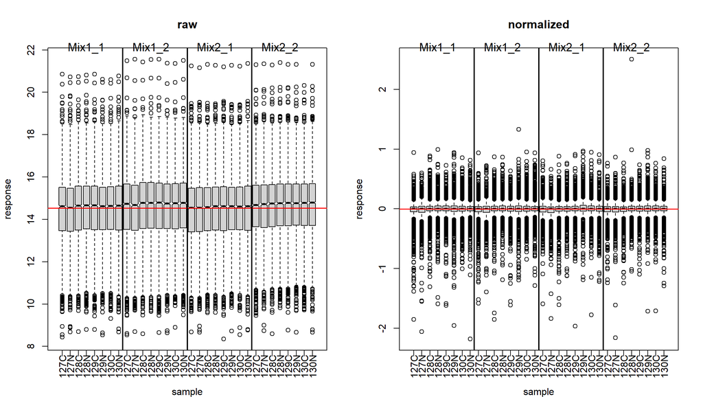

```r
# use (half-)wide format
par(mfrow=c(1,2))
boxplot_w(dat.nonnorm.summ.w,sample.info, 'raw')
boxplot_w(dat.norm.summ.w, sample.info, 'normalized')
```

## 5.2 MA plots

MA plots of two single samples taken from condition 1 and condition 0.125, measured in different MS runs (samples *Mixture2_1:127C* and *Mixture1_2:129N*, respectively).

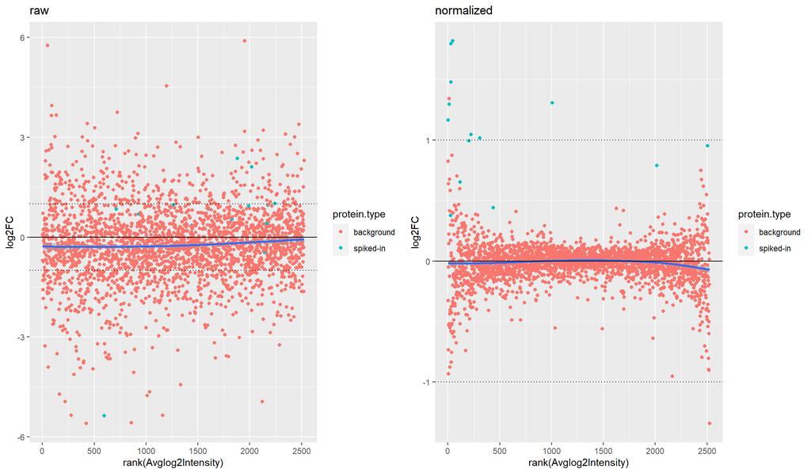

```r
# use wide2 format
p1 <- maplot_ils(dat.nonnorm.summ.w2, 'Mixture2_1:127C', 'Mixture1_2:129N', scale='log', 'raw', spiked.proteins)
p2 <- maplot_ils(dat.norm.summ.w2, 'Mixture2_1:127C', 'Mixture1_2:129N', scale='log', 'normalized', spiked.proteins)
grid.arrange(p1, p2, ncol=2)
```

MA plots of all samples from condition `1` and condition `0.125` (quantification values averaged within condition).

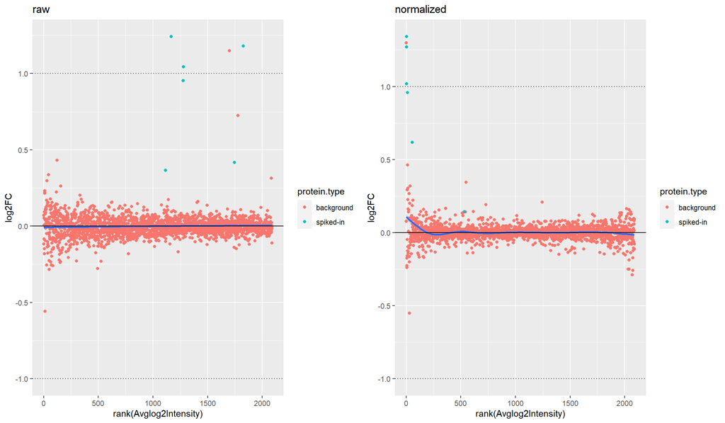

```r
channels.num <- sample.info %>% filter(Condition=='1') %>% select(Sample) %>% pull
channels.denom <- sample.info %>% filter(Condition=='0.125') %>% select(Sample) %>% pull
p1 <- maplot_ils(dat.nonnorm.summ.w2, channels.num, channels.denom, scale='log', 'raw', spiked.proteins)
p2 <- maplot_ils(dat.norm.summ.w2, channels.num, channels.denom, scale='log', 'normalized', spiked.proteins)
grid.arrange(p1, p2, ncol=2)
```

## 5.3 PCA plots

### 5.3.1 Using all proteins

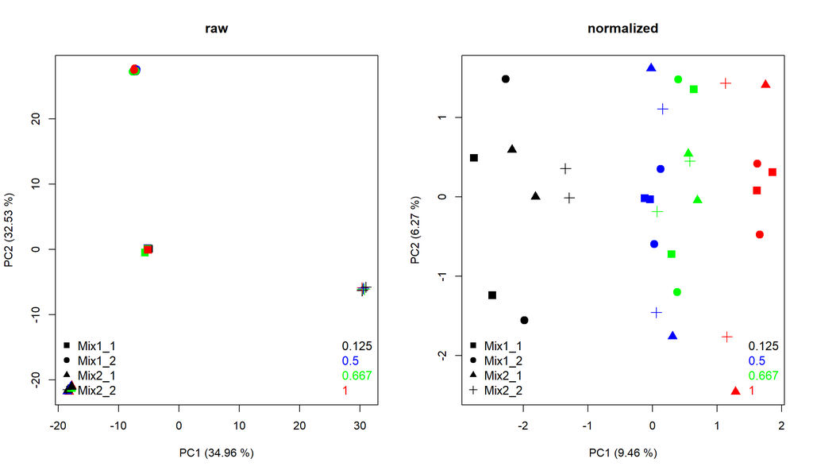

```r
par(mfrow=c(1, 2))
pcaplot_ils(dat.nonnorm.summ.w2 %>% select(-'Protein'), info=sample.info, 'raw')
pcaplot_ils(dat.norm.summ.w2 %>% select(-'Protein'), info=sample.info, 'normalized')
```

### 5.3.2 Using spiked proteins only

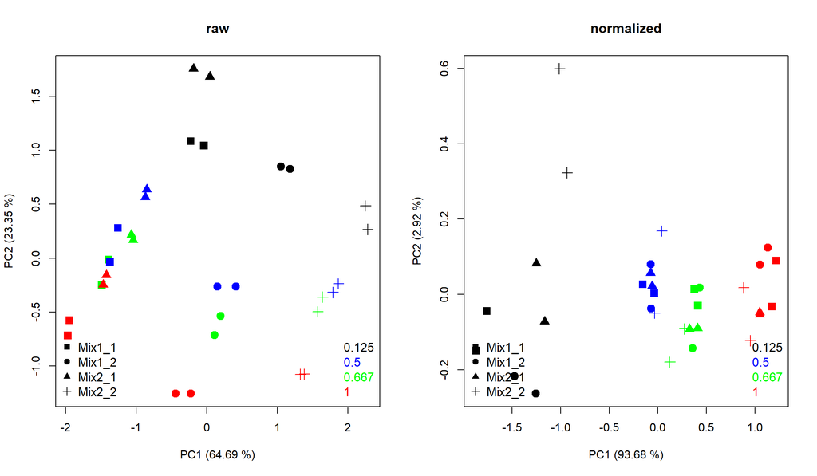

```r
par(mfrow=c(1, 2))
pcaplot_ils(dat.nonnorm.summ.w2 %>% filter(Protein %in% spiked.proteins) %>% select(-'Protein'), info=sample.info, 'raw')
pcaplot_ils(dat.norm.summ.w2 %>% filter(Protein %in% spiked.proteins) %>% select(-'Protein'), info=sample.info, 'normalized')
```

## 5.4 HC (hierarchical clustering) plots

### 5.4.1 Using all proteins

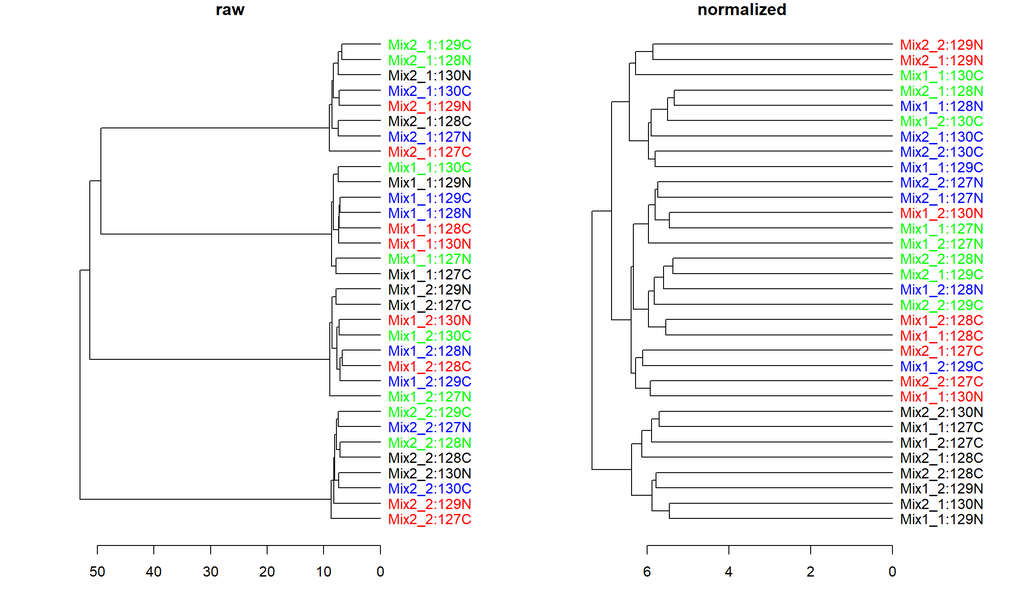

```r
par(mfrow=c(1, 2))
dendrogram_ils(dat.nonnorm.summ.w2 %>% select(-Protein), info=sample.info, 'raw')
dendrogram_ils(dat.norm.summ.w2 %>% select(-Protein), info=sample.info, 'normalized')
```

## 5.5 Run effect p-value plot

Below the histograms of p-values from the linear model explaining the response variable with Run as a covariate.

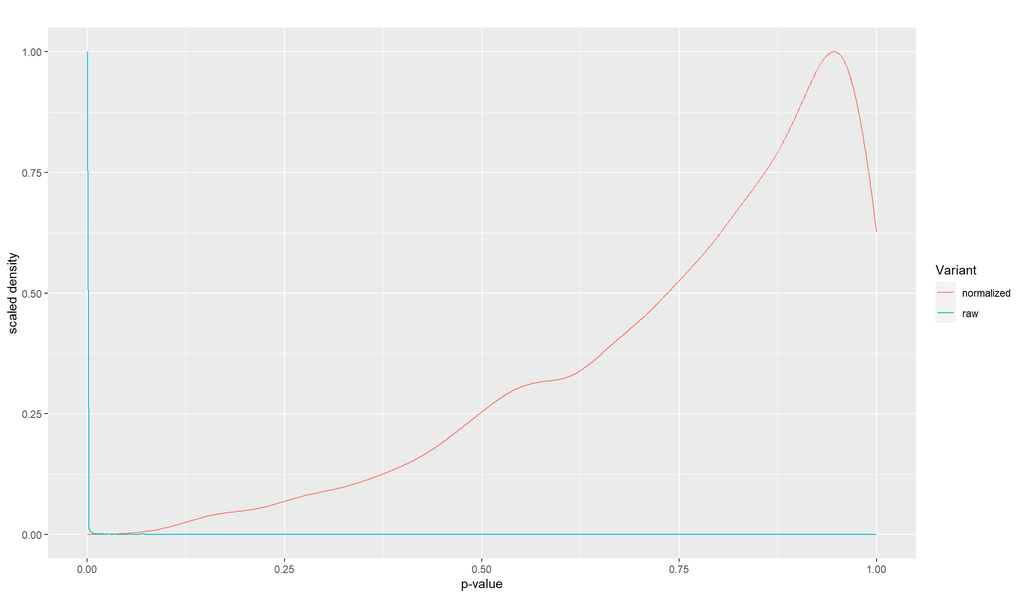

```r
dat <- list(dat.nonnorm.summ.l,dat.norm.summ.l)
names(dat) <- c('raw','normalized')
run_effect_plot(dat)
```

# 6 DEA component

## 6.1 Moderated t-test

TODO: - Also try to log-transform the intensity case, to see if there are large differences in the t-test results. - done. remove this code? NOTE: - actually, lmFit (used in moderated_ttest) was built for log2-transformed data. However, supplying untransformed intensities can also work. This just means that the effects in the linear model are also additive on the untransformed scale, whereas for log-transformed data they are multiplicative on the untransformed scale. Also, there may be a bias which occurs from biased estimates of the population means in the t-tests, as mean(X) is not equal to exp(mean(log(X))).

```r
if (!load_outputdata){
design.matrix <- get_design_matrix(referenceCondition, sample.info)
dat.dea <- emptyList(variant.names)
this_scale <- scale.vec
d <- column_to_rownames(as.data.frame(dat.norm.summ.w2), 'Protein')
dat.dea$moderated_ttest <- moderated_ttest(dat=d, design.matrix, scale=this_scale)
}
```

## 6.2 Wilcoxon test

```r
if (!load_outputdata){
otherConditions <- dat.l %>% distinct(Condition) %>% pull(Condition) %>% as.character %>% sort
otherConditions <- otherConditions[-match(referenceCondition, otherConditions)]
dat.dea$Wilcoxon <- wilcoxon_test(dat.norm.summ.w2, sample.info, referenceCondition, otherConditions, logFC.method='ratio')
}
```

## 6.3 Permutation test

```r
if (!load_outputdata){
dat.dea$permutation_test <- permutation_test(dat.norm.summ.l, referenceCondition, otherConditions, seed=seed, distribution='exact')
}
```

## 6.4 ROTS

```r
if (!load_outputdata){
dat.dea$ROTS <- rots_test(dat.norm.summ.w2, referenceCondition, otherConditions)
}
```

# 7 Results comparison

## 7.1 Confusion matrix

```r
cm <- conf_mat(dat.dea, 'q.mod', 0.05, spiked.proteins)
print_conf_mat(cm, referenceCondition)
```

|  | 0.125 vs 0.5 contrast moderated_ttest background | 0.125 vs 0.5 contrast moderated_ttest spiked | 0.125 vs 0.5 contrast Wilcoxon background | 0.125 vs 0.5 contrast Wilcoxon spiked | 0.125 vs 0.5 contrast permutation_test background | 0.125 vs 0.5 contrast permutation_test spiked | 0.125 vs 0.5 contrast ROTS background | 0.125 vs 0.5 contrast ROTS spiked |
| --- | --- | --- | --- | --- | --- | --- | --- | --- |
| not_DE | 4061 | 4 | 4064 | 19 | 4064 | 19 | 4063 | 15 |
| DE | 3 | 15 | 0 | 0 | 0 | 0 | 1 | 4 |

|  | 0.125 vs 0.5 contrast moderated_ttest | 0.125 vs 0.5 contrast Wilcoxon | 0.125 vs 0.5 contrast permutation_test | 0.125 vs 0.5 contrast ROTS |
| --- | --- | --- | --- | --- |
| Accuracy | 0.998 | 0.995 | 0.995 | 0.996 |
| Sensitivity | 0.789 | 0.000 | 0.000 | 0.211 |
| Specificity | 0.999 | 1.000 | 1.000 | 1.000 |
| PPV | 0.833 | NaN | NaN | 0.800 |
| NPV | 0.999 | 0.995 | 0.995 | 0.996 |

|  | 0.667 vs 0.5 contrast moderated_ttest background | 0.667 vs 0.5 contrast moderated_ttest spiked | 0.667 vs 0.5 contrast Wilcoxon background | 0.667 vs 0.5 contrast Wilcoxon spiked | 0.667 vs 0.5 contrast permutation_test background | 0.667 vs 0.5 contrast permutation_test spiked | 0.667 vs 0.5 contrast ROTS background | 0.667 vs 0.5 contrast ROTS spiked |
| --- | --- | --- | --- | --- | --- | --- | --- | --- |
| not_DE | 4062 | 17 | 4064 | 19 | 4064 | 19 | 4064 | 19 |
| DE | 2 | 2 | 0 | 0 | 0 | 0 | 0 | 0 |

|  | 0.667 vs 0.5 contrast moderated_ttest | 0.667 vs 0.5 contrast Wilcoxon | 0.667 vs 0.5 contrast permutation_test | 0.667 vs 0.5 contrast ROTS |
| --- | --- | --- | --- | --- |
| Accuracy | 0.995 | 0.995 | 0.995 | 0.995 |
| Sensitivity | 0.105 | 0.000 | 0.000 | 0.000 |
| Specificity | 1.000 | 1.000 | 1.000 | 1.000 |
| PPV | 0.500 | NaN | NaN | NaN |
| NPV | 0.996 | 0.995 | 0.995 | 0.995 |

|  | 1 vs 0.5 contrast moderated_ttest background | 1 vs 0.5 contrast moderated_ttest spiked | 1 vs 0.5 contrast Wilcoxon background | 1 vs 0.5 contrast Wilcoxon spiked | 1 vs 0.5 contrast permutation_test background | 1 vs 0.5 contrast permutation_test spiked | 1 vs 0.5 contrast ROTS background | 1 vs 0.5 contrast ROTS spiked |
| --- | --- | --- | --- | --- | --- | --- | --- | --- |
| not_DE | 4060 | 5 | 4064 | 19 | 4064 | 19 | 4064 | 18 |
| DE | 4 | 14 | 0 | 0 | 0 | 0 | 0 | 1 |

|  | 1 vs 0.5 contrast moderated_ttest | 1 vs 0.5 contrast Wilcoxon | 1 vs 0.5 contrast permutation_test | 1 vs 0.5 contrast ROTS |
| --- | --- | --- | --- | --- |
| Accuracy | 0.998 | 0.995 | 0.995 | 0.996 |
| Sensitivity | 0.737 | 0.000 | 0.000 | 0.053 |
| Specificity | 0.999 | 1.000 | 1.000 | 1.000 |
| PPV | 0.778 | NaN | NaN | 1.000 |
| NPV | 0.999 | 0.995 | 0.995 | 0.996 |

## 7.2 Scatter plots

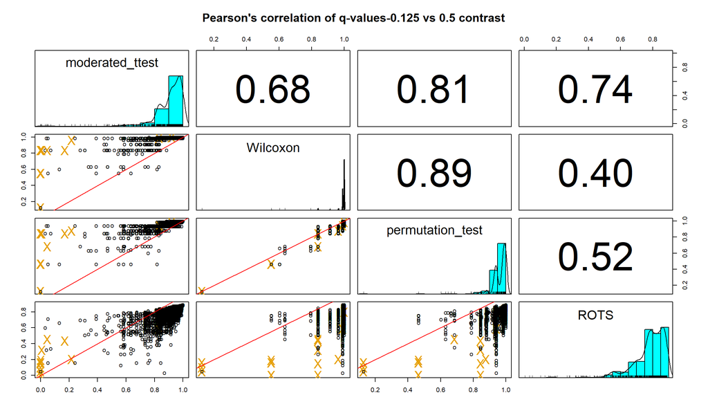

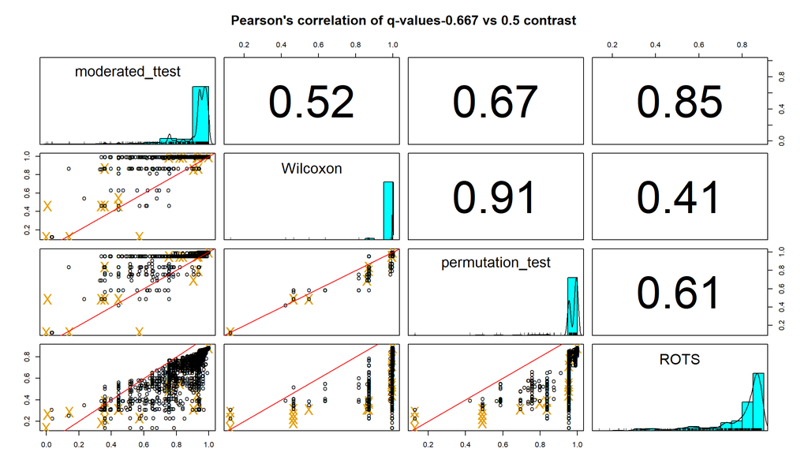

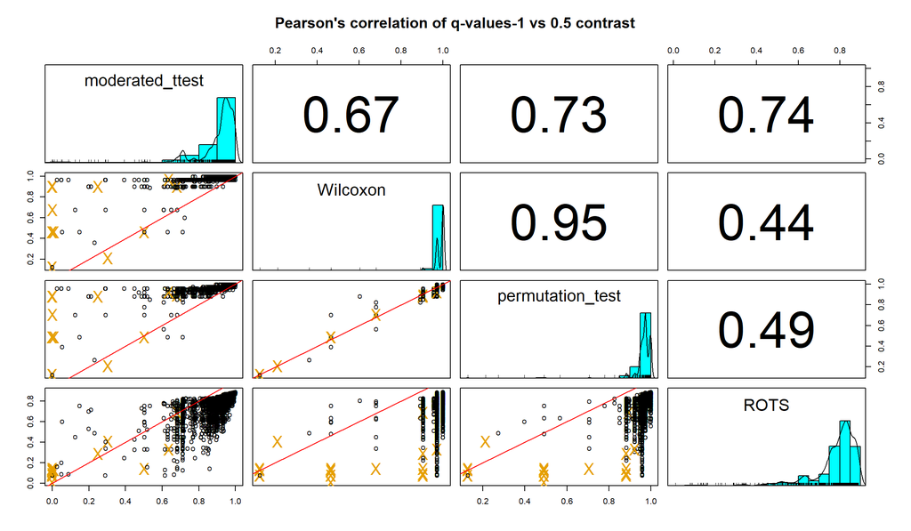

```r
# character vectors containing logFC and p-values columns
dea.cols <- colnames(dat.dea[[1]])
logFC.cols <- dea.cols[stri_detect_fixed(dea.cols, 'logFC')]
significance.cols <- dea.cols[stri_detect_fixed(dea.cols, 'q.mod')]
n.contrasts <- length(logFC.cols)

scatterplot_ils(dat.dea, significance.cols, 'q-values', spiked.proteins)
```

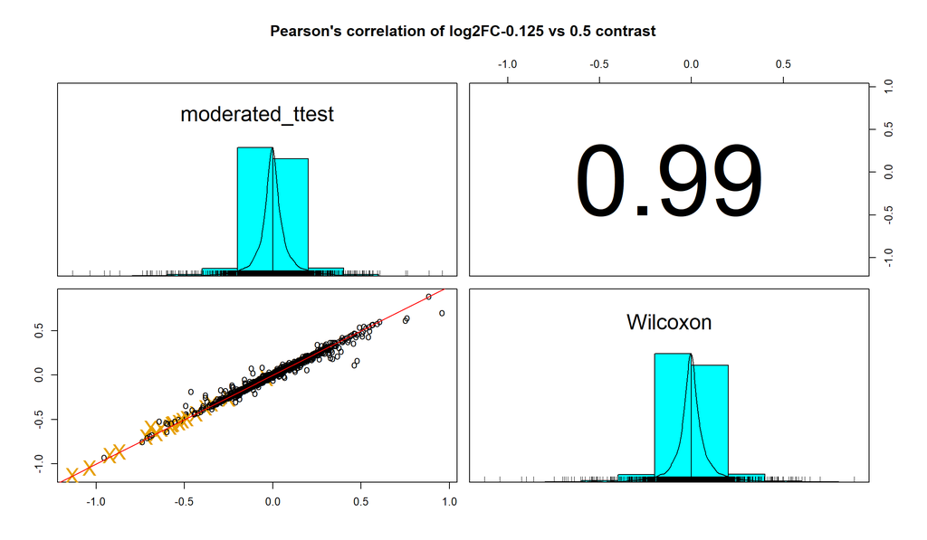

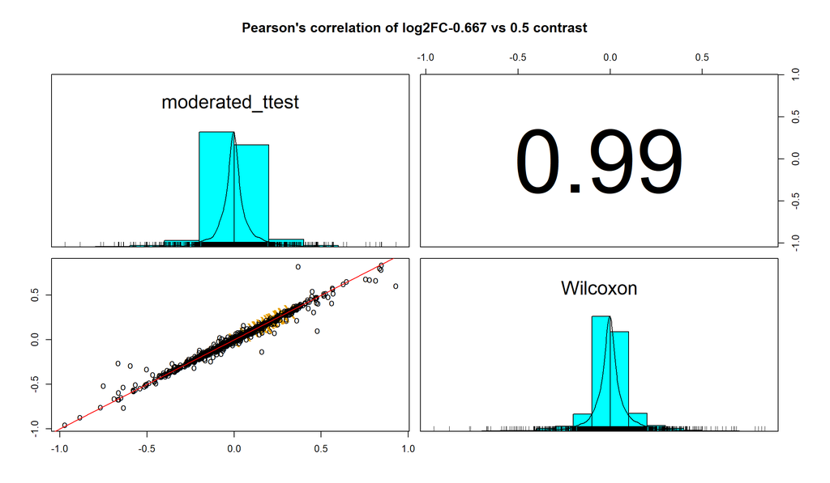

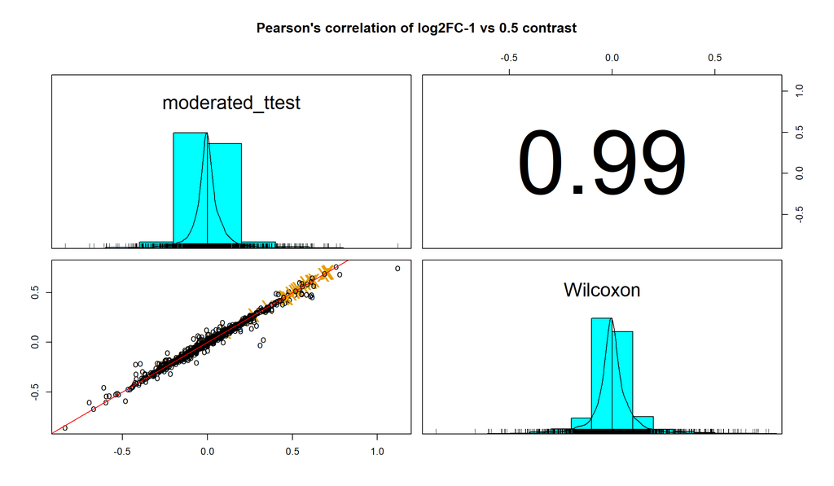

```r
scatterplot_ils(dat.dea[c('moderated_ttest', 'Wilcoxon')], logFC.cols, 'log2FC', spiked.proteins)
```

## 7.3 Volcano plots

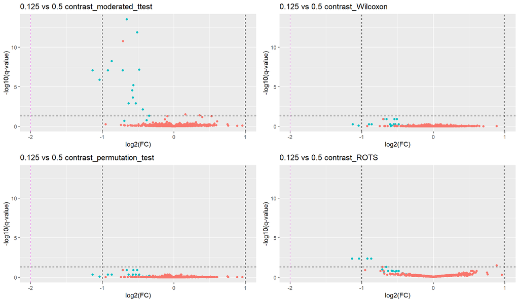

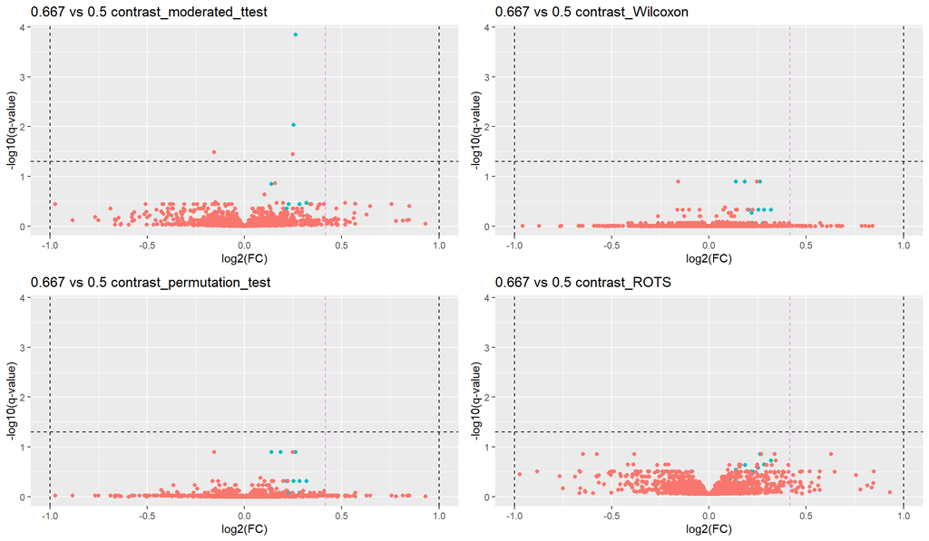

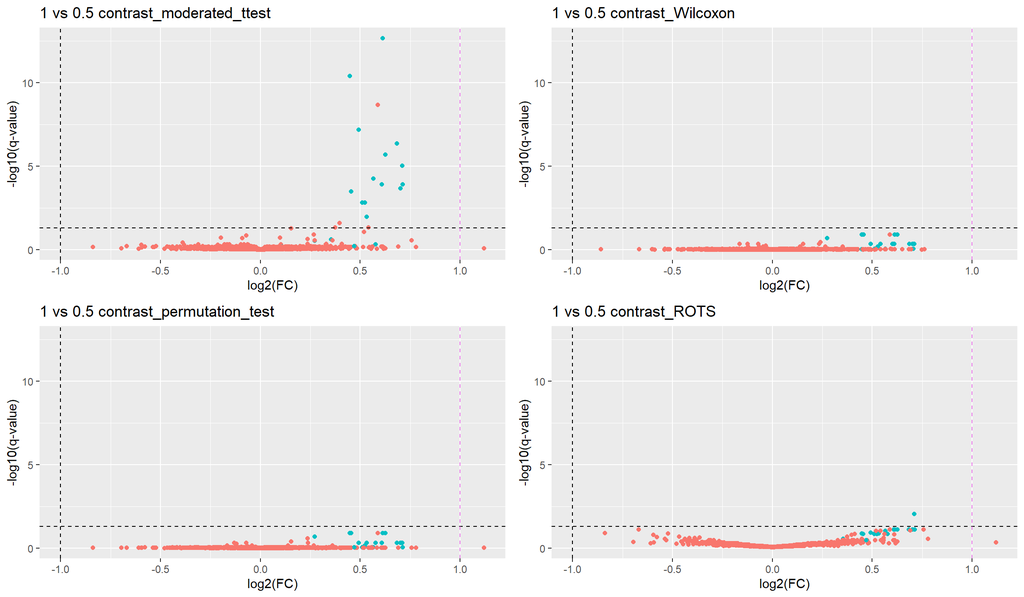

```r
for (i in 1:n.contrasts){
  volcanoplot_ils(dat.dea, i, spiked.proteins)}
```

## 7.4 Violin plots

Let’s see whether the spiked protein fold changes make sense

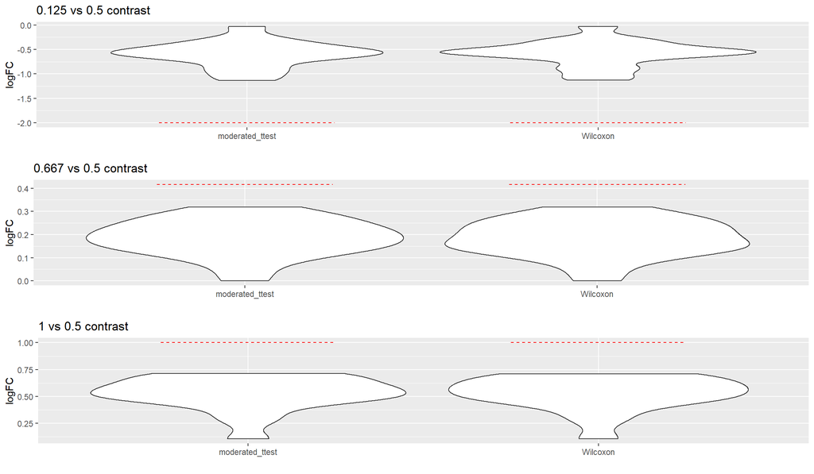

```r
# plot theoretical value (horizontal lines) and violin per variant
violinplot_ils(lapply(dat.dea[c('moderated_ttest', 'Wilcoxon')], function(x) x[spiked.proteins, logFC.cols]), referenceCondition)
```

# 8 Conclusions